# Hands-on Practical: Generalised Additive Models (GAMs) with Bioluminescence

StatGeoMod2025 — 1.5-hour practical

Emil Bogs

21 September 2025

## Part A — Why GAMs? (Basics & intuition) (10 min)

**Task A1 (concept).**

A GAM replaces a single global slope with a **smooth function** $f(x): Y_i = \alpha + f(X_i) + \varepsilon_i$.

In `mgcv`, `s(x)` builds $f(x)$ from spline bases, and smoothness is selected automatically (REML/GCV).

**Task A2 (visual).**

**What you’ll do (and why):**

1. **Prepare the data.** Select only Station 16 from the ISIT dataset and create a clean dataframe with three variables: `Station`, `Depth`, and `Sources`.
2. **Inspect the structure.** Use `glimpse()` to confirm that `Depth` is numeric (continuous predictor) and `Sources` is count data (non-negative integers). This step helps you check if the data type matches the modelling assumptions later.
3. **Visualise.** Make a scatterplot of Sources vs Depth using `ggplot2`. Adjust the transparency (`alpha = 0.7`) to help visualise overlapping points. Add informative labels and a minimal theme.
4. **Interpret.** After plotting, pause to describe what you see:
   - Is the pattern approximately linear, or clearly non-linear?
   - Are there regions of the depth gradient where Sources increase, peak, or decline?
   - Would fitting a straight line capture the overall shape, or would it miss important features?

This visual exploration sets the stage for why GAMs are needed: we often encounter curved, irregular, or locally varying relationships that polynomials or linear fits cannot capture well.

```r
## Fill in the blanks (`___`) in the code below.
#| label: A2-plot
# Prepare Station 16
dat <- ISIT |>
  dplyr::filter(Station == 16) |>
  transmute(Station,
            Depth   = SampleDepth,
            Sources = Sources)

# Quick look
head(dat)
```

```
## # A tibble: 6 × 3
##   Station Depth Sources
##     <dbl> <dbl>   <dbl>
## 1      16   598    53.4
## 2      16   631    51.3
## 3      16   700    42.4
## 4      16   666    38.3
## 5      16  1317    37.3
## 6      16  1352    36.3
```

```r
summary(dat)
```

```
##     Station       Depth         Sources
##  Min.   :16   Min.   : 598   Min.   : 0.00
##  1st Qu.:16   1st Qu.:1669   1st Qu.: 1.37
##  Median :16   Median :2744   Median : 4.11
##  Mean   :16   Mean   :2713   Mean   :12.48
##  3rd Qu.:16   3rd Qu.:3793   3rd Qu.:25.66
##  Max.   :16   Max.   :4866   Max.   :53.37
```

```r
glimpse(dat)
```

```
## Rows: 51
## Columns: 3
## $ Station <dbl> 16, 16, 16, 16, 16, 16, 16, 16, 16, 16, 16, 16, 16, 16, 16, 16…
## $ Depth   <dbl> 598, 631, 700, 666, 1317, 1352, 1417, 1386, 938, 1009, 974, 16…
## $ Sources <dbl> 53.37, 51.32, 42.42, 38.32, 37.29, 36.27, 32.16, 31.82, 28.74,…
```

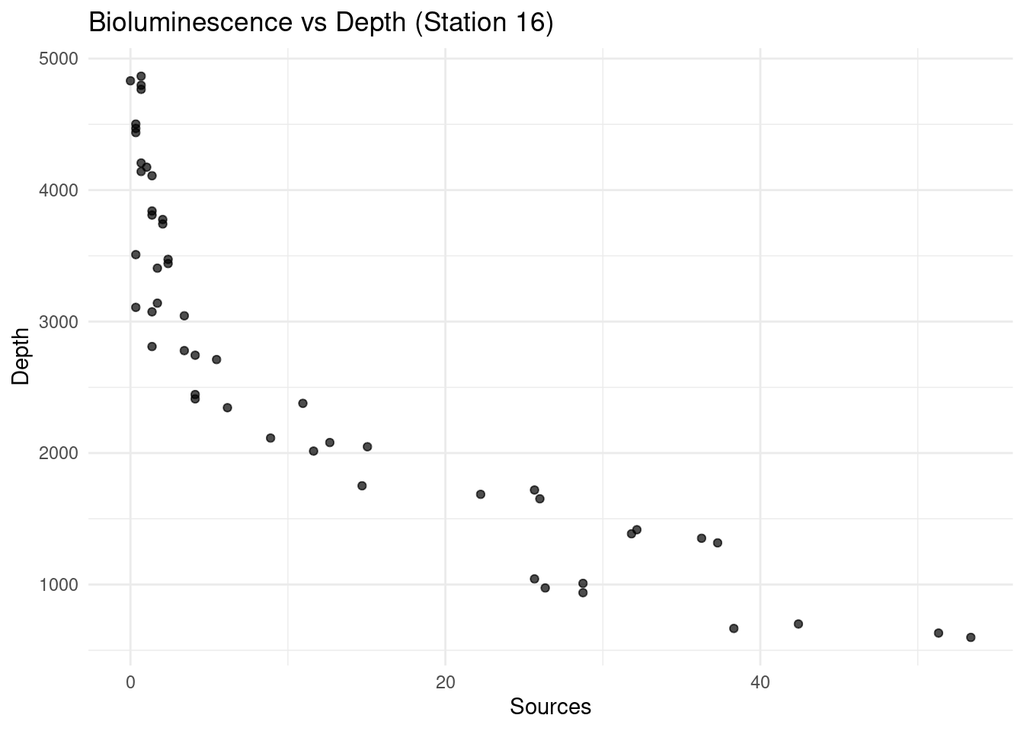

```r
# Visualise
ggplot(dat, aes(Sources, Depth)) +
  geom_point(alpha = 0.7) +
  labs(title = "Bioluminescence vs Depth (Station 16)",
       y = "Depth") +
  theme_minimal()
```

**Questions**.

## Part B — First GAM vs Polynomial (Runge motivation) (20 min)

**Task B1 — Fit your first GAM (cubic regression spline)**

**What you’ll do (and why):**

- **Model:** Fit a GAM to `Sources ~ s(Depth)` using a **cubic regression spline** (`bs = "cr"`).
- **Smoothing selection:** Use **REML** (`method = "REML"`) so the model estimates the amount of smoothing (λ) automatically—balancing wiggliness and over-penalisation.
- **Complexity (edf):** Inspect **effective degrees of freedom (edf)** in `summary()` to gauge curve flexibility ($\approx$ 1 is almost linear; larger edf = more curvature).
- **Diagnostics:** Use `gam.check()` to examine residual patterns, QQ plot, scale–location, and the **k-index** (basis adequacy). A **low k-index** suggests increasing `k` (the basis dimension) and refitting.
- **Outcome:** You’ll see how GAMs adapt to the clear non-linearity in the bioluminescence vs depth relationship (Station 16) without resorting to high-degree polynomials.

**Hints for robust modelling:** - Start with the default `k` (mgcv chooses a sensible basis size), then **only** increase it if `gam.check()` warns (k-index < ~1).  
- Prefer **REML** over GCV for smoother, more stable fits in many practical settings.  
- Always validate: smooth fit $\neq$ good residuals—check both.

```r
# Fill in the blanks (___) and then set eval: true to run
# Goal: Fit a GAM with a cubic regression spline and inspect diagnostics

# 1) Fit the model (use REML for smoothing selection)
m_gam <- gam(Sources ~ s(Depth, bs = "cr"), data = dat, method = "REML")

# 2) Summarise: check edf, significance of s(), adjusted R^2, and REML score
summary(m_gam)
```

```
##
## Family: gaussian
## Link function: identity
##
## Formula:
## Sources ~ s(Depth, bs = "cr")
##
## Parametric coefficients:
##             Estimate Std. Error t value Pr(>|t|)
## (Intercept)  12.4771     0.3745   33.32   <2e-16 ***
## ---
## Signif. codes:  0 '***' 0.001 '**' 0.01 '*' 0.05 '.' 0.1 ' ' 1
##
## Approximate significance of smooth terms:
##            edf Ref.df     F p-value
## s(Depth) 8.518  8.933 175.3  <2e-16 ***
## ---
## Signif. codes:  0 '***' 0.001 '**' 0.01 '*' 0.05 '.' 0.1 ' ' 1
##
## R-sq.(adj) =  0.969   Deviance explained = 97.4%
## -REML = 137.09  Scale est. = 7.1531    n = 51
```

```r
AIC(m_gam)
```

```
## [1] 256.3402
```

```r
# 3) Diagnostics: residual patterns and k-index
par(mfrow = c(2, 2))
gam.check(m_gam)
```

```
##
## Method: REML   Optimizer: outer newton
## full convergence after 5 iterations.
## Gradient range [-8.224855e-09,4.09595e-09]
## (score 137.0912 & scale 7.153119).
## Hessian positive definite, eigenvalue range [2.295059,25.13629].
## Model rank =  10 / 10
##
## Basis dimension (k) checking results. Low p-value (k-index<1) may
## indicate that k is too low, especially if edf is close to k'.
##
##            k'  edf k-index p-value
## s(Depth) 9.00 8.52    1.04    0.58
```

```r
par(mfrow = c(1, 1))
```

**Question**

- **Shape check:** What does the fitted smooth suggest about how `Sources` changes with `Depth` (e.g., monotonic, hump-shaped, thresholds)? *The deeper it gets the less sources are available in general. But there is an exception around 1000m there are less sources (~30) then at 1400 (~35) afterwards it declines again. AT around 3000 it reaches a plateau of around 0.*
- **Complexity:** What is the reported **edf**, and how would you interpret that value in plain language? *The reported edf is 8.5, it estimates the complexity of the created smoothed curved it seems complex but not exesssively.*
- **Adequacy:** Does `gam.check()` indicate any **patterned residuals** or **basis inadequacy** (k-index warnings)? If yes, what would you try next? *The gam check schows patterns of residuals, which tells us that our model is not adequate enough. But we dont have any k-index warning as k-index is higher then 1 and the corresponding p-value is not significant. Nevertheless we should try something else:*
- **Comparative lens:** In what ways would a polynomial of degree 4–6 likely behave differently at the **edges** of the `Depth` range (Runge-type behaviour)? *I think the polynomial of 4-6 degrees would go through the points at the end and therby oscillate strongly like the runge type behaviour.*

**Task B2 — Plot the GAM on the response scale with uncertainty**

**What you’ll do (and why):**

- **Purpose:** Turn the fitted GAM into an interpretable plot on the **response scale**, so students see predicted *Sources* against *Depth* in real units.
- **Prediction grid:** Create a fine, evenly spaced depth grid to avoid jagged lines from irregular sampling.
- **Uncertainty:** Use `predict(..., se.fit = TRUE, type = "response")` to obtain fitted values and their **standard errors** on the response scale. Add a ribbon for an approximate **95% pointwise interval** using `fit ± 2 * se.fit`.
- **Visual clarity:** Overlay the fitted line and ribbon on the raw data to contrast modelled trend vs. observed scatter.

**Key ideas:** - `type = "response"` ensures predictions are on the scale of *Sources* (not the link/linear predictor). - The ribbon is **pointwise**, not simultaneous; it’s excellent for teaching uncertainty, but do not over-interpret it as a joint interval over the whole curve. - Dense grids (e.g., 300–500 points) give smooth lines without oversmoothing the model itself.

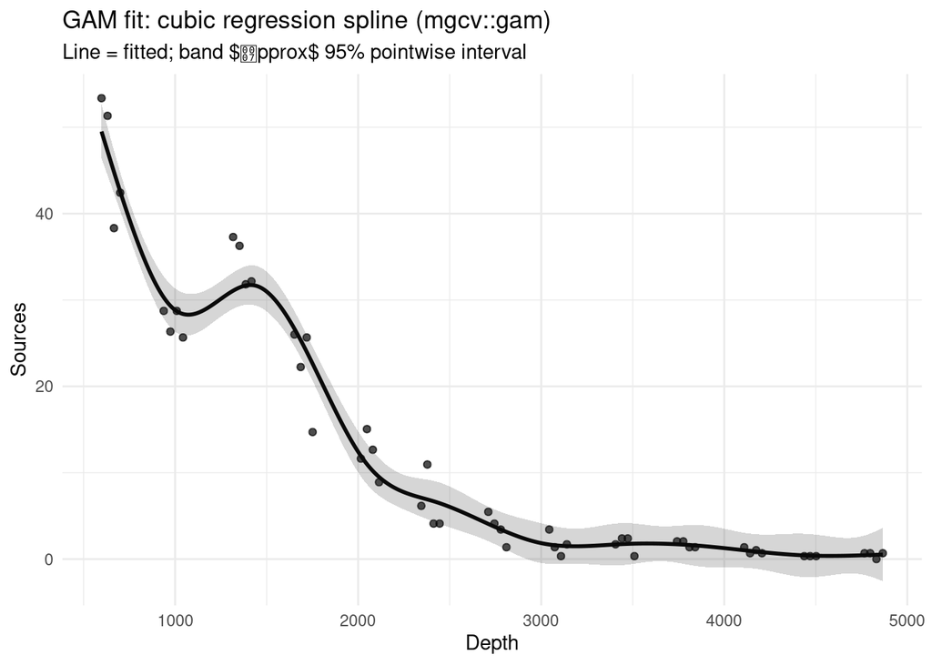

```r
#fill in the blanks (___) and then set eval: true to run
# Goal: Plot the GAM fit on the response scale with ~95% pointwise intervals

# 1) Create a prediction grid over Depth
newd <- tibble(Depth = seq(min(dat$Depth), max(dat$Depth), length.out = 400))

# 2) Predict on the response scale with standard errors
pred_gam <- bind_cols(
  newd,
  as_tibble(predict(m_gam, newd, se.fit = TRUE, type = "response"))
)

# 3) Plot: points, fitted line, and ribbon for uncertainty
ggplot(dat, aes(Depth, Sources)) +
  geom_point(alpha = 0.7) +
  geom_line(data = pred_gam, aes(y = fit), linewidth = 1) +
  geom_ribbon(data = pred_gam,
              aes(y = fit,
                  ymin = fit - 2*se.fit,
                  ymax = fit + 2*se.fit),
              alpha = 0.2) +
  labs(title = "GAM fit: cubic regression spline (mgcv::gam)",
       subtitle = "Line = fitted; band $\approx$ 95% pointwise interval",
       y = "Sources") +
  theme_minimal()
```

**Questions**

- **Scale check:** Why is `type = "response"` preferable here compared to `type = "link"`? *Because it this way you get the predictions in the sacle of the response.*
- **Uncertainty:** What does the shaded band represent, and where does it widen most? Why might that be? *The ribbon represents the area in ihich 95%of the point used for that fitted line should lay.*
- **Edge behaviour:** Do you see wider intervals near minimum/maximum depth? How does sampling density play a role?  
  *We see a little bit bigger intervals towards the min and max because of the Runges phenomenon but its not really strong.*
- **Interpretation:** Identify depth ranges where the fitted curve rises, plateaus, or falls. How would a straight-line model mislead here? *Same answer as earlier*

**What you’ll do (and why):**

**Key ideas:** - **Global vs local flexibility:** Global polynomials force one equation to capture the entire curve; GAM smooths adapt locally with a penalty on wiggliness.  
- **Edge effects:** Extrapolation/oscillation at the **depth extremes** is common with higher-degree polynomials (Runge-type behaviour).  
- **Model selection:** AIC can be computed for each polynomial, but shape realism and diagnostics matter just as much as a single metric.

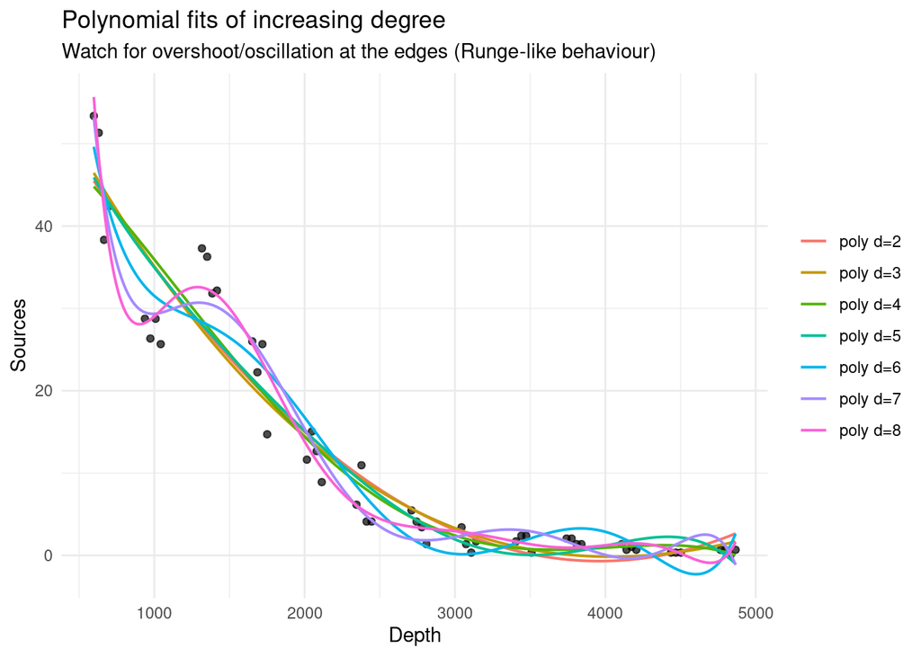

```r
#fill in the blanks (___) and then set eval: true to run
# Goal: Fit polynomial regressions (degrees 2–6) and compare shapes to the GAM

# 0) Ensure you have a prediction grid (from Task B2); if not, create it:
# newd <- tibble(Depth = seq(min(___$___), max(___$___), length.out = ___))

# 1) Choose degrees to compare
deg_seq <- 2:8   # e.g., 2:6

# 2) Fit polynomials, predict on 'newd', and collect results
fits_poly <- map_df(deg_seq, ~{
  fm   <- lm(Sources ~ poly(Depth, .x, raw = TRUE), data = dat)
  pred <- predict(fm, newd, se.fit = TRUE)
  tibble(
    Depth = newd$Depth,
    fit   = as.numeric(pred$fit),
    se    = pred$se.fit,
    deg   = paste0("poly d=", .x),
    AIC   = AIC(fm)[1]
  )
})


# 3) Plot: raw data + polynomial fits
ggplot(dat, aes(Depth, Sources)) +
  geom_point(alpha = 0.7) +
  geom_line(data = fits_poly, aes(y = fit, colour = deg), linewidth = 0.7) +
  labs(title = "Polynomial fits of increasing degree",
       subtitle = "Watch for overshoot/oscillation at the edges (Runge-like behaviour)",
       colour = NULL) +
  theme_minimal()
```

**Questions**

- **Overshoot zones:** At which depth ranges do the higher-degree polynomials deviate most from the data (overshoot/oscillation)? *AT the areas where the points are most scattered.*
- **Edge stability:** How does the **GAM** behave at shallowest/deepest depths compared with polynomials of degree ≥ 4?  
  *GAM actually “oscillates” way stronger then polynomials of the degree 4 as the GAM describes the individual points stronger*
- **Parsimony vs realism:** If a degree-5 polynomial shows a slightly lower AIC than degree-3, would you still prefer the GAM? Why?  
  *Yes i would still prefer GAM as with increasing degrees of polynomials also the degrees of freedom increase and thereby the fit which is calculated by AIC gets better but also the possibility because of an missunderstnading of the complexity can occur. GAM doesnt get an as low AIC but is a better fit according to showing the complexity of the data.*
- **Prediction risk:** What practical risks arise if stakeholders act on edge-unstable predictions (e.g., setting thresholds at range limits)? *The Predictions could be either to high or to low therefor stakeholders could expect to profit more or less of something and thereby take wrong meassures.*

## Part C — How GAMs work (inner workings, lightly) (10 min)

**Task C1 (concept).**

In `mgcv`, $f(x)$ is built from spline **basis functions** with a smoothness penalty ($\lambda$).

Optimal $\lambda$ is estimated by REML or GCV; larger $\lambda \Rightarrow$ smoother curve. **edf** (in `summary()`) reflects the effective flexibility.

**Task C2 (hands-on) — Vary the basis dimension `k` to confirm adequacy**

**What you’ll do (and why):**

- **Purpose:** Check whether the chosen spline **basis size** (`k`) is large enough to capture the signal without imposing an artificial ceiling on model flexibility.
- **How it works:** In `mgcv`, `k` sets the **maximum** complexity of the smooth; the model then estimates the **effective degrees of freedom (edf)** via REML/GCV. Typically, `edf ≤ k - 1` for cubic regression splines.
- **Underspecification risk:** If `k` is too small, the smoother may be **forced** to be too simple even if the penalty would allow more wiggle—this leads to biased fits.
- **Diagnostics:** Use `gam.check()`’s **k-index** test. Warnings (low k-index and small p-values) suggest increasing `k` and refitting. If increasing `k` does **not** change the fitted curve or edf materially, the smaller `k` is sufficient.
- **Practical tip:** Start modest (e.g., `k=10`), increase to a larger value (e.g., `k=30`), compare `edf`, AIC, and residual diagnostics. With REML, a **too-large** `k` is usually safe (penalty controls overfitting), but avoid excessively huge `k` for computation and concurvity stability.

```r
#fill in the blanks (___) and then set eval: true to run
# Goal: Compare k=10 vs k=30, inspect edf/AIC, and check k-index in gam.check()

# 1) Fit two GAMs with different basis dimensions
m_k10 <- gam(Sources ~ s(Depth, bs = "cr", k = 10), data = dat, method = "REML")
m_k30 <- gam(Sources ~ s(Depth, bs = "cr", k = 30), data = dat, method = "REML")

# 2) Compare model summaries (edf, R^2, etc.) at a glance
bind_rows(
  broom::glance(m_k10) %>% dplyr::mutate(model = "k=10"),
  broom::glance(m_k30) %>% dplyr::mutate(model = "k=30")
) %>%
  dplyr::select(model, df = df.residual, AIC, deviance, r.squared = adj.r.squared)
```

```
## # A tibble: 2 × 5
##   model    df   AIC deviance r.squared
##   <chr> <dbl> <dbl>    <dbl>     <dbl>
## 1 k=10   41.5  256.     297.     0.969
## 2 k=30   37.1  243.     192.     0.978
```

```r
# 3) Diagnostics: residual patterns & basis adequacy (k-index)
par(mfrow = c(2, 2))
gam.check(m_k10)
```

```
##
## Method: REML   Optimizer: outer newton
## full convergence after 5 iterations.
## Gradient range [-8.224855e-09,4.09595e-09]
## (score 137.0912 & scale 7.153119).
## Hessian positive definite, eigenvalue range [2.295059,25.13629].
## Model rank =  10 / 10
##
## Basis dimension (k) checking results. Low p-value (k-index<1) may
## indicate that k is too low, especially if edf is close to k'.
##
##            k'  edf k-index p-value
## s(Depth) 9.00 8.52    1.04    0.59
```

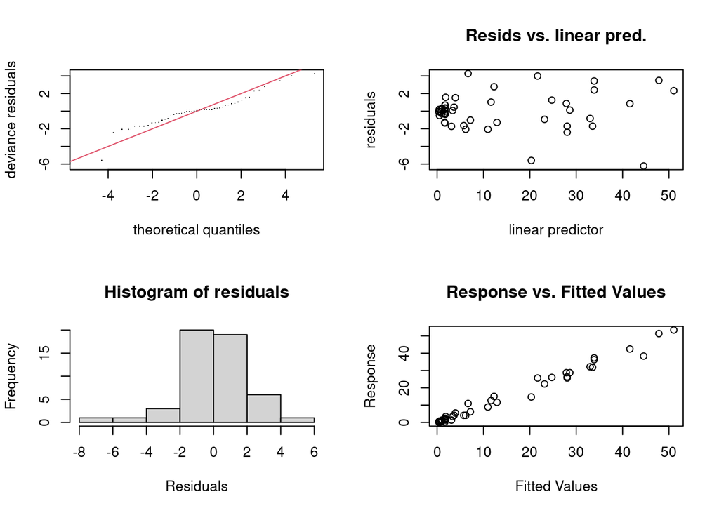

```
##
## Method: REML   Optimizer: outer newton
## full convergence after 5 iterations.
## Gradient range [-2.248653e-06,2.099473e-07]
## (score 133.8975 & scale 5.16161).
## Hessian positive definite, eigenvalue range [2.981623,26.13621].
## Model rank =  30 / 30
##
## Basis dimension (k) checking results. Low p-value (k-index<1) may
## indicate that k is too low, especially if edf is close to k'.
##
##            k'  edf k-index p-value
## s(Depth) 29.0 12.9    1.34    0.99
```

```r
gam.check(m_k30)
```

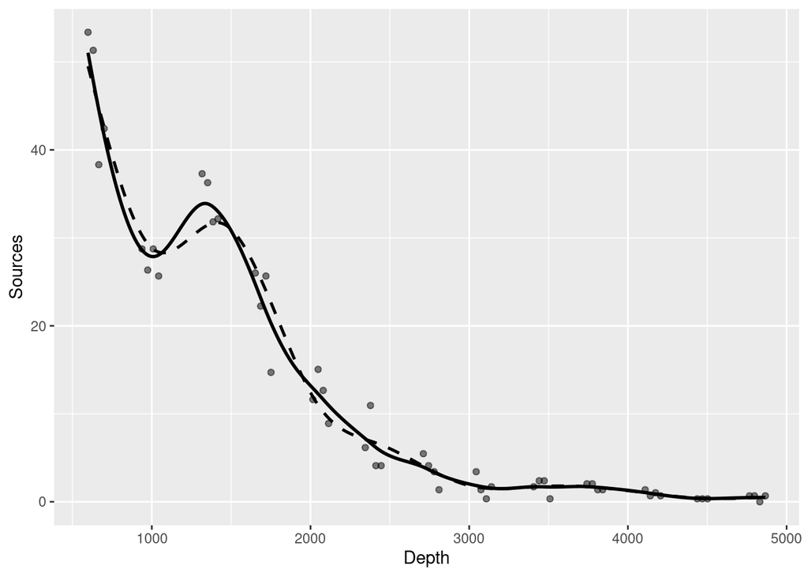

```r
par(mfrow = c(1, 1))

# Optional (for visual comparison): overlay fitted curves
# newd <- tibble(Depth = seq(min(___$___), max(___$___), length.out = 400))
 pred10 <- dplyr::bind_cols(newd, as_tibble(predict(m_k10, newd, se.fit = TRUE, type = "response")))
 pred30 <- dplyr::bind_cols(newd, as_tibble(predict(m_k30, newd, se.fit = TRUE, type = "response")))
 ggplot(dat, aes(Depth, Sources)) +
   geom_point(alpha = 0.5) +
   geom_line(data = pred10, aes(y = fit), linewidth = 0.9, linetype = 2) +
   geom_line(data = pred30, aes(y = fit), linewidth = 1)
```

```r
 summary(m_k10)
```

```
##
## Family: gaussian
## Link function: identity
##
## Formula:
## Sources ~ s(Depth, bs = "cr", k = 10)
##
## Parametric coefficients:
##             Estimate Std. Error t value Pr(>|t|)
## (Intercept)  12.4771     0.3745   33.32   <2e-16 ***
## ---
## Signif. codes:  0 '***' 0.001 '**' 0.01 '*' 0.05 '.' 0.1 ' ' 1
##
## Approximate significance of smooth terms:
##            edf Ref.df     F p-value
## s(Depth) 8.518  8.933 175.3  <2e-16 ***
## ---
## Signif. codes:  0 '***' 0.001 '**' 0.01 '*' 0.05 '.' 0.1 ' ' 1
##
## R-sq.(adj) =  0.969   Deviance explained = 97.4%
## -REML = 137.09  Scale est. = 7.1531    n = 51
```

```r
 summary(m_k30)
```

```
##
## Family: gaussian
## Link function: identity
##
## Formula:
## Sources ~ s(Depth, bs = "cr", k = 30)
##
## Parametric coefficients:
##             Estimate Std. Error t value Pr(>|t|)
## (Intercept)  12.4771     0.3181   39.22   <2e-16 ***
## ---
## Signif. codes:  0 '***' 0.001 '**' 0.01 '*' 0.05 '.' 0.1 ' ' 1
##
## Approximate significance of smooth terms:
##            edf Ref.df     F p-value
## s(Depth) 12.87  15.14 144.1  <2e-16 ***
## ---
## Signif. codes:  0 '***' 0.001 '**' 0.01 '*' 0.05 '.' 0.1 ' ' 1
##
## R-sq.(adj) =  0.978   Deviance explained = 98.3%
## -REML =  133.9  Scale est. = 5.1616    n = 51
```

**Questions**

## Part D — GAMs vs GLMs (what changes?) (10 min)

**Task D1 — Fit a GLM (Gaussian identity) and compare with the GAM**

**What you’ll do (and why):**

- **Baseline model:** Fit a **GLM with Gaussian errors and identity link**: `Sources ~ Depth`. This is the linear benchmark against which we compare the GAM.
- **Model comparison:** Use **AIC** to compare `m_glm` vs `m_gam`. Lower AIC indicates a better trade-off between fit and complexity.
- **Diagnostics:** Inspect residuals of **both** models. Even with Gaussian errors, a linear mean structure can be misspecified if the *shape* is non-linear; GAMs can capture this via a smooth `s(Depth)`.
- **Takeaway:** A GAM can outperform a linear GLM under Gaussian errors when the **systematic component** (mean–covariate relation) is curved.

**Practical tips:** - A lower AIC for the GAM alongside cleaner residuals supports non-linearity in the mean.  
- If AICs are close, prioritise **diagnostics** and **interpretability** (edge behaviour, residual structure).

```r
#fill in the blanks (___) and then set eval: true to run
# Goal: Fit a Gaussian-identity GLM and compare with the GAM via AIC; inspect residuals.

# 1) Fit the baseline GLM (linear mean)
m_glm <- glm(Sources ~ Depth, data = dat, family = gaussian())

# 2) Compare to GAM via AIC
AIC(m_glm, m_gam)
```

```
##             df      AIC
## m_glm  3.00000 355.1904
## m_gam 10.89895 256.3402
```

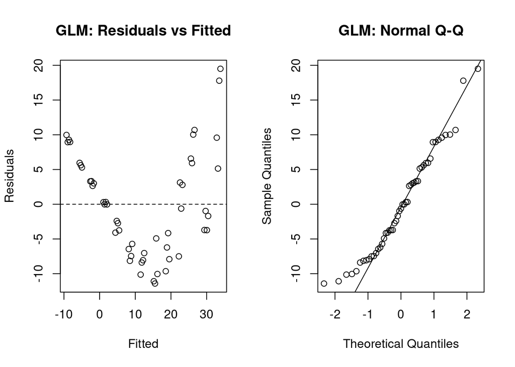

```r
# 3) Quick residual diagnostics (GLM): residuals–fitted and QQ
par(mfrow = c(1, 2))
plot(fitted(m_glm), residuals(m_glm), main = "GLM: Residuals vs Fitted",
     xlab = "Fitted", ylab = "Residuals"); abline(h = 0, lty = 2)
qqnorm(residuals(m_glm), main = "GLM: Normal Q-Q"); qqline(residuals(m_glm))
```

```r
par(mfrow = c(1, 1))

# 4) (Optional) Re-run GAM diagnostics here for side-by-side judgement
 #par(mfrow = c(2, 2)); gam.check(___); par(mfrow = c(1, 1))
```

- **AIC verdict:** Which model has the lower AIC? Is the difference large enough to be compelling (> ~2–4)?  
  *m_gam has a lower AIC by 100 which is very compelling.*
- **Residual patterns:** Do you see curvature in **GLM** residuals vs fitted values that disappears in the **GAM**?  
  *Yes we see curvature.*
- **Model misspecification:** Why can a linear GLM be inadequate even if Gaussian error assumptions roughly hold? *because its not suited to the non linear distribution of the points.*
- **Communication:** How would you explain to stakeholders why a smooth (GAM) is preferable here over a straight line? *as explained earlier it better explains the real relationship in nature.* :::

## Part E — Model fit & selection (15 min)

**Task E1 — Compare alternative GAMs: different bases and smoothness criteria**

**What you’ll do (and why):**

- **Purpose:** To explore how GAM fits depend on the **choice of spline basis** and the **method for smoothing parameter estimation**.
- **Spline bases compared:**
  - `"cr"` = **cubic regression spline** — efficient and common default.
  - `"tp"` = **thin plate regression spline** — more flexible, recommended when smoothness complexity is unknown.
  - `"cs"` = **cubic regression spline with shrinkage** — like `"cr"`, but allows the smoother to shrink towards 0 if unsupported by data (useful in model selection).
- **Smoothing selection methods:**
  - **REML (Restricted Maximum Likelihood):** generally more stable and conservative.
  - **GCV.Cp (Generalised Cross Validation):** can be faster but sometimes under-smooths.
- **Approach:** Fit three models with the same data but different combinations of basis and smoothing method, then compare them using **AIC**.

**Key message:** If the AIC values and fitted curves are similar, the choice of basis/method is less critical. Differences may matter in small samples or when doing **variable selection**.

```r
#fill in the blanks (___) and then set eval: true to run
# Goal: Compare GAMs with different spline bases and smoothing selection criteria

# 1) Fit GAMs with different bases and methods
# Fit three GAMs with different bases/methods
# Cubic regression spline with REML smoothing parameter selection
m_cr_reml <- gam(Sources ~ s(Depth, bs = "cr"), data = dat, method = "REML")
# Thin plate regression spline with GCV.Cp smoothing parameter selection
m_tp_gcv  <- gam(Sources ~ s(Depth, bs = "tp"), data = dat, method = "GCV.Cp")
# Cubic regression spline with shrinkage and REML smoothing parameter selection
m_cs_reml <- gam(Sources ~ s(Depth, bs = "cs"), data = dat, method = "REML")   # cubic shrinkage

# 2) Compare the models using AIC
AIC(m_cr_reml, m_tp_gcv, m_cs_reml)
```

```
##                 df      AIC
## m_cr_reml 10.89895 256.3402
## m_tp_gcv  10.81301 260.4811
## m_cs_reml 10.90882 256.8646
```

**Task E2 — Diagnostics and concurvity**

**What you’ll do (and why):**

- **Residual diagnostics:** Use `gam.check()` to assess whether the model assumptions hold. This produces:
  - Residuals vs fitted values (should show no clear pattern).
  - Q-Q plot of residuals (should be close to the line if residuals are Gaussian).
  - Scale–location plot (homogeneity of variance).
  - Histogram of residuals.
  - **k-index test** for basis dimension adequacy (low k-index suggests `k` may be too small).
- **Concurvity diagnostics:** Use `concurvity()` to check for strong correlations between smooth terms.
  - Concurvity is like multicollinearity but for smooths.
  - Values close to 1 indicate redundancy between smooths, which can make interpretation unstable.
  - With only one smooth term (as in this example), concurvity isn’t a problem but running it introduces the concept for when you add more predictors.

**Key message:** A GAM is only trustworthy if residual diagnostics look reasonable and concurvity is low. Always validate your model fit before interpreting smooths.

**Decision prompt.** Pick a “best” model using AIC + diagnostics + interpretability. State your choice and why (method, edf, residuals).

```r
##| label: E2-diag-student
#| echo: true
#fill in the blanks (___) and then set eval: true to run
# Goal: Run model diagnostics (gam.check) and assess concurvity

# 1) Residual diagnostics for the chosen model
par(mfrow = c(2, 2))
gam.check(m_cr_reml)
```

```
##
## Method: REML   Optimizer: outer newton
## full convergence after 5 iterations.
## Gradient range [-8.224855e-09,4.09595e-09]
## (score 137.0912 & scale 7.153119).
## Hessian positive definite, eigenvalue range [2.295059,25.13629].
## Model rank =  10 / 10
##
## Basis dimension (k) checking results. Low p-value (k-index<1) may
## indicate that k is too low, especially if edf is close to k'.
##
##            k'  edf k-index p-value
## s(Depth) 9.00 8.52    1.04    0.56
```

```r
par(mfrow = c(1, 1))
# 2) Concurvity assessment (more relevant with multiple smooths)
concurvity(m_cr_reml, full = TRUE)
```

```
##          para     s(Depth)
## worst       0 2.803904e-32
## observed    0 5.532021e-33
## estimate    0 2.514071e-33
```

```r
# (add-on) — Visual residuals–fitted overlay with ggplot2**
## **What you’ll do (and why):**
## - Create a tidy data frame of **fitted values** (on the response scale) and **Pearson residuals** from your chosen GAM (e.g. `m_cr_reml`).
## - Plot **residuals vs fitted** using `ggplot2`, add a **zero reference line**, and a light **LOESS trend** to spot structure.
## - This complements `gam.check()` with a modern diagnostic visual and makes it easy to layer aesthetics if needed (e.g., colour by a factor).
# Goal: Build a ggplot residuals–fitted overlay for your chosen GAM (e.g., m_cr_reml)
# 1) Create a small diagnostics tibble with fitted values and Pearson residuals
#diag_df <- tibble(
#  fitted = fitted(___, type = "___"),
#  resid  = residuals(___, type = "___")
#)

# 2) Plot residuals vs fitted with a LOESS guide
#ggplot(diag_df, aes(x = ___, y = ___)) +
#  geom_hline(yintercept = 0, linetype = 2) +
#  geom_point(alpha = ___) +
#  geom_smooth(method = "loess", se = FALSE, span = 0.8) +
#  labs(title = "Residuals vs Fitted (GAM)",
#       x = "Fitted values",
#       y = "Pearson residuals") +
#  theme_minimal()
```

**Questions**

- **Residuals:** Do the residual plots suggest non-linearity, heteroscedasticity, or non-normality?  
  *its linear and normal distributed, but maybe heteroscedasticit*
- **k-index:** Does `gam.check()` suggest that the basis size `k` was adequate? If not, what would you try next? *K index was slightly higher then one we could increase k a bit to be safe.*
- **Concurvity:** Why is concurvity not an issue here, but critical when you have multiple smooth terms? *because the values of s depth are close to 0 and thereby no concurvity is expected.*
- **Practice:** How would high concurvity affect your interpretation of a GAM with two correlated covariates? *it would show make it difficult to see which of the covariats effects the response in which way so we could just analyse their effects combined.*

## Part F — Beyond a single station: Station effect + one smooth (15 min)

**Task F1 — Two-station example with a shared smooth and a station shift**

**What you’ll do (and why):**

- **Purpose:** Combine Stations **8** and **13** and model a **common depth effect** via a single smooth `s(Depth)` while allowing a **parametric shift** between stations (an intercept difference via `+ Station`).
- **Depth overlap:** Restrict both stations to the **shared depth range** so that the common smooth isn’t biased by non-overlapping extremes (a classic source of spurious differences).
- **Model:** `Sources ~ s(Depth, bs="cr") + Station` with **REML** smoothing selection.
- **Inference:** Use `summary()` and `anova()` to assess:
  - the **shape and significance** of `s(Depth)` (edf, F, p)
  - whether **Station** has a significant **offset** (parametric coefficient)

```r
#fill in the blanks (___) and then set eval: true to run
# Goal: Fit a GAM with a shared smooth over Depth and a parametric Station shift

# 1) Subset Stations 8 and 13; keep key variables
d2 <- ISIT |>
  dplyr::filter(Station %in% c(8, 13)) |>
  dplyr::transmute(Station = factor(Station),
                   Depth   = SampleDepth,
                   Sources = Sources)

# 2) Restrict to shared Depth overlap
rng <- d2 |>
  dplyr::group_by(Station) |>
  dplyr::summarise(mn = min(Depth), mx = max(Depth), .groups = "drop")
lo  <- max(rng$mn); hi <- min(rng$mx)
d2o <- d2 |>
  dplyr::filter(Depth > lo, Depth < hi)

# 3) Fit shared-smooth + station-offset model
m_two <- mgcv::gam(Sources ~ s(Depth, bs = "cr") + Station, data = d2o, method = "REML")

# 4) Inspect results
summary(m_two)
```

```
##
## Family: gaussian
## Link function: identity
##
## Formula:
## Sources ~ s(Depth, bs = "cr") + Station
##
## Parametric coefficients:
##             Estimate Std. Error t value Pr(>|t|)
## (Intercept)   19.219      1.061  18.117  < 2e-16 ***
## Station13    -12.333      1.404  -8.781 7.67e-13 ***
## ---
## Signif. codes:  0 '***' 0.001 '**' 0.01 '*' 0.05 '.' 0.1 ' ' 1
##
## Approximate significance of smooth terms:
##            edf Ref.df     F p-value
## s(Depth) 4.237  5.191 16.18  <2e-16 ***
## ---
## Signif. codes:  0 '***' 0.001 '**' 0.01 '*' 0.05 '.' 0.1 ' ' 1
##
## R-sq.(adj) =   0.69   Deviance explained = 71.2%
## -REML = 239.37  Scale est. = 35.77     n = 75
```

```r
anova(m_two)
```

```
##
## Family: gaussian
## Link function: identity
##
## Formula:
## Sources ~ s(Depth, bs = "cr") + Station
##
## Parametric Terms:
##         df     F  p-value
## Station  1 77.11 7.67e-13
##
## Approximate significance of smooth terms:
##            edf Ref.df     F p-value
## s(Depth) 4.237  5.191 16.18  <2e-16
```

**Questions**

**Task F2 — Plot the common smooth with a station offset**

**What you’ll do (and why):** - **Purpose:** Visualise the fitted **shared smooth over Depth** with a **station-specific intercept shift** from **Task F1**. This lets you see whether a single curve shape plus a vertical offset captures both stations adequately.  
- **Prediction grid:** Build a tidy grid over the **common depth range** (`d2o`) for **each station** so the offset appears as parallel curves with identical shapes.  
- **Uncertainty:** Use `predict(..., se.fit = TRUE, type = "response")` to obtain fitted values and pointwise SEs on the **response scale**. Plot ribbons as ~95% intervals (`fit ± 2*se.fit`).  
- **Visual cues:** Scatter the raw data by station, overlay the station-wise fitted lines, and add ribbons to compare fit quality across stations and depths.

**Key idea:** If the curves appear **parallel** (same shape, vertical shift), the shared-smooth + station-offset model is appropriate. If shapes visibly diverge, consider **by-smooths** (`s(Depth, by = Station) + Station`).

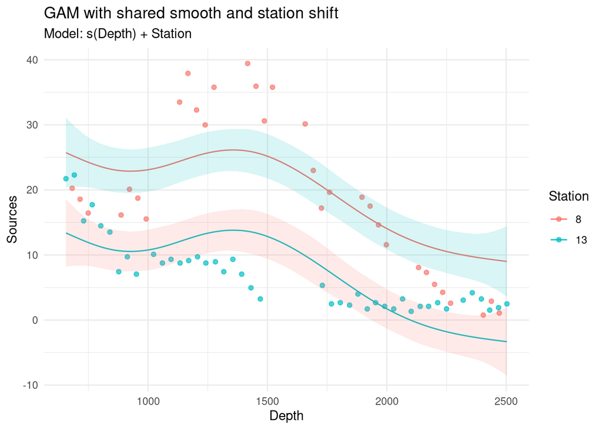

```r
#fill in the blanks (___) and then set eval: true to run
# Goal: Plot the common smooth + station offset with uncertainty bands

# 1) Build a prediction grid over the common depth range for each station
new2 <- tidyr::expand_grid(
  Depth   = seq(min(d2o$Depth), max(d2o$Depth), length.out = 400),
  Station = levels(d2o$Station)
)

# 2) Predict on the response scale with standard errors
p2 <- dplyr::bind_cols(
  new2,
  as_tibble(predict(m_two, new2, se.fit = TRUE, type = "response"))
)

# 3) Plot raw data + fitted lines + ribbons
ggplot(d2o, aes(Depth, Sources, colour = Station)) +
  geom_point(alpha = 0.7) +
  geom_line(data = p2, aes(y = fit)) +
  geom_ribbon(data = p2,
              aes(y = fit,
                  ymin = fit - 2*se.fit,
                  ymax = fit + 2*se.fit,
                  fill = Station),
              alpha = 0.15, colour = NA) +
  labs(title = "GAM with shared smooth and station shift",
       subtitle = "Model: s(Depth) + Station") +
  theme_minimal() +
  guides(fill = "none")
```

**Questions**

- **Parallelism:** Do the two fitted lines look **parallel** across the depth range? If not, where do they diverge most? *Yes they look very parallel.*
- **Uncertainty:** Where are the ribbons widest? Is that due to sparse data or genuine variability? *the ribbons are widdest at the beginning and end, probably because of sparse data.*
- **Fit adequacy:** Are there systematic zones where one station’s data consistently sits above/below the fitted line?  
  *For station 18 we can see a cluster over the band around 1200-1600 Depth and for Station 13 we see a cluster underneath for 900-1500.*
- **Next model:** If shapes differ, how would **by-smooths** change the specification and interpretation? *It would show diffrent shape profiles for each station.*

## Part G — Expanding GAMs: Beyond Gaussian (10 min)

**Task G1 — Count responses: Poisson vs Negative Binomial GAMs + overdispersion check**

**What you’ll do (and why):** - **Motivation:** `Sources` are non-negative counts. Gaussian GAMs can fit the mean curve but ignore count-like mean–variance structure.  
- **Families:**  
- **Poisson**: $\mathbb{E}[Y]=\mu$, $\mathrm{Var}(Y)=\mu$ (equidispersion).  
- **Negative Binomial (NB)**: $\mathrm{Var}(Y)=\mu + \mu^2/\theta$ (extra-Poisson/overdispersion handled by $\theta$).  
- **Approach:** Fit `Poisson` and `NB` GAMs with the same smoother as before, compare **AIC**, and check **overdispersion** (Poisson).  
- **Overdispersion rule of thumb:** If $\text{ratio} = \frac{\text{residual deviance}}{\text{df residual}} \gtrsim 1.5\!-\!2$, Poisson is likely too restrictive → prefer **NB**.  
- **Outcome:** You’ll decide whether a count family yields better fit/diagnostics than the Gaussian GAM.

**Notes:**  
- `type="response"` predictions keep the plot in data units.  
- With counts and small means, consider using **Pearson** residuals for checks.

```r
# Round the Sources to force a count
#| label: G1-counts-student
#| echo: true
#fill in the blanks (___) and then set eval: true to run
# Goal: Fit Poisson and NB GAMs for count data, compare AIC, and check overdispersion


# Round the Sources to force a count
dat$rnd.Sources <- round(dat$Sources)
# 1) Fit count-family GAMs with the same smoother used before
m_pois <- mgcv::gam(rnd.Sources ~ s(Depth, bs = "cr"), data = dat, family = poisson(), method = "REML")
m_nb   <- mgcv::gam(rnd.Sources ~ s(Depth, bs = "cr"), data = dat, family = nb(),    method = "REML")

# 2) Compare AICs (Gaussian vs Poisson vs NB)
AIC(m_gam, m_pois, m_nb)
```

```
##               df      AIC
## m_gam  10.898947 256.3402
## m_pois  7.244334 212.6014
## m_nb    8.244346 214.6016
```

```r
# 3) Quick Poisson overdispersion checks
# (a) Residual deviance / df
with(broom::glance(m_pois), deviance / df.residual)
```

```
## [1] 0.7052789
```

```r
# (b) Pearson chi-square / df (often more informative)
chi_phi <- sum(residuals(m_pois, type = "pearson")^2) / df.residual(m_pois)
chi_phi
```

```
## [1] 0.5832494
```

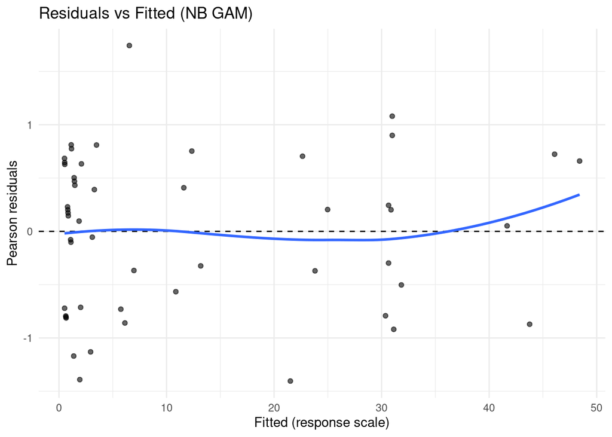

```r
#OPTIONAL: Visual residuals–fitted overlay for NB model
diag_nb <- tibble(fitted = fitted(m_nb, type = "response"),
                  resid  = residuals(m_nb, type = "pearson"))
ggplot(diag_nb, aes(fitted, resid)) +
  geom_hline(yintercept = 0, linetype = 2) +
  geom_point(alpha = 0.6) +
  geom_smooth(method = "loess", se = FALSE, span = 0.8) +
  labs(title = "Residuals vs Fitted (NB GAM)",
        x = "Fitted (response scale)", y = "Pearson residuals") +
   theme_minimal()
```

**Questions**

- **AIC & diagnostics:** Do Poisson/NB improve AIC versus the Gaussian GAM? What happens to residual patterns? *the lowest AIC is for m_pois followed closely by m_nb and thenwith a wide gap comes m_gam. So yes they improve AIC.*
- **Dispersion:** What is the Poisson dispersion ratio? If high, how does NB change the picture? *We dont see really overdispersion vfor poisson so nb is not needed.*
- **Interpretation:** How do you explain (to non-statisticians) the practical difference between **GAM (Gaussian)** and **GAM (Poisson/NB)** for these data?  
  *Poisson and NB take into account counts not random continuous numbers like gam and can thereby improve the models fit.*
- **Next steps:** If NB still shows structure, what else might you try (offsets, additional covariates, alternative links, zero-inflation, etc.)? *This i dont know yet.*

## Summary of the Practical

This practical introduced students to the use of Generalised Additive Models (GAMs) through the bioluminescence depth dataset. We began by visualising raw data at single stations, highlighting the inadequacy of linear fits and motivating the need for flexible smoothers. By fitting cubic regression splines in mgcv::gam, students explored the principle of replacing fixed parametric terms with smooth functions to capture non-linear relationships.

We contrasted GAMs with polynomial regressions, which can mimic non-linearity but suffer from instability at range edges (Runge’s phenomenon). This emphasised why GAMs are preferable: they avoid oscillations, allow local flexibility, and are regularised through penalisation. The role of the basis dimension (k) and smoothing parameter (λ) was examined, with diagnostic tools (gam.check, residual plots, k-index) showing how to assess adequacy and avoid under/over-smoothing.

We extended the models by comparing different spline bases (cubic regression, thin-plate, shrinkage) and smoothness criteria (REML, GCV). Students practised evaluating model fit with AIC and concurvity checks, reinforcing that GAMs retain the statistical rigour of GLMs while offering flexibility. A comparison between GLMs and GAMs (Gaussian identity) demonstrated why GAMs often outperform when relationships are non-linear, even with the same error family.

Building complexity, we modelled multiple stations with shared smooths and parametric shifts, and discussed when by-smooths are preferable. Finally, the practical illustrated GAMs beyond Gaussian responses, fitting Poisson and Negative Binomial GAMs to count data, and highlighting the importance of overdispersion checks.

Overall, the session showed that GAMs form a natural extension of regression models:

- From a single smoother (non-linear regression replacement),
- Through diagnostics and model selection,
- To flexible multi-station and non-Gaussian applications.

**Key Take-Home Points** * GAMs extend GLMs by allowing smooth, data-driven functional forms for predictors. * Polynomials $\neq$ smoothers: GAMs avoid Runge’s phenomenon and handle local variation better. * Diagnostics matter: always check gam.check, AIC, and concurvity before trusting results. * Flexible families: GAMs work with Gaussian, Poisson, binomial, NB, and beyond. * Interpretation: Smooth terms represent shapes, not single coefficients — describe curves, not slopes.